# Analisis Regresi Linier Ganda (Tugas 2 Bagian C)

### Persamaan regresi dugaan

```r
# Perhitungan menggunakan fungsi lm di program R
mod.reg <- lm(delTime~n.prod+distance)
summary(mod.reg)
```

```
##
## Call:
## lm(formula = delTime ~ n.prod + distance)
##
## Residuals:
##     Min      1Q  Median      3Q     Max
## -5.7880 -0.6629  0.4364  1.1566  7.4197
##
## Coefficients:
##             Estimate Std. Error t value Pr(>|t|)
## (Intercept) 2.341231   1.096730   2.135 0.044170 *
## n.prod      1.615907   0.170735   9.464 3.25e-09 ***
## distance    0.014385   0.003613   3.981 0.000631 ***
## ---
## Signif. codes:  0 '***' 0.001 '**' 0.01 '*' 0.05 '.' 0.1 ' ' 1
##
## Residual standard error: 3.259 on 22 degrees of freedom
## Multiple R-squared:  0.9596, Adjusted R-squared:  0.9559
## F-statistic: 261.2 on 2 and 22 DF,  p-value: 4.687e-16
```

```r
# Perhitungan secara manual di program R
X <- cbind(1, n.prod, distance)
Y <- delTime
b <- solve(t(X)%*%X)%*%t(X)%*%Y
b
```

```
##                [,1]
##          2.34123115
## n.prod   1.61590721
## distance 0.01438483
```

Persamaan regresi dugaan yang dihasilkan adalah:

$$\hat{Y} = 2.3412 + 1.6159X_1 + 0.0144X_2$$

- **Intersep**: Nilai intersep ($b_0$) adalah 2.3412. Ini menunjukkan bahwa saat jumlah produk ($n.prod$) dan jarak ($distance$) sama dengan 0, waktu pengiriman ($delTime$) diperkirakan sebesar 2.3412 unit. Namun, dalam konteks praktis, nilai intersep ini mungkin tidak memiliki makna yang signifikan karena nilai nol untuk kedua variabel prediktor mungkin tidak relevan atau mungkin tidak mungkin dalam konteks yang sesungguhnya.
- **Koefisien untuk $n.prod$**: Koefisien untuk $n.prod$ ($b_1$) adalah 1.6159. Ini menunjukkan bahwa jika jumlah produk ($n.prod$) meningkat sebesar 1 unit dan jarak ($distance$) tetap, waktu pengiriman ($delTime$) diperkirakan akan meningkat sekitar 1.6159 unit.
- **Koefisien untuk $distance$**: Koefisien untuk $distance$ ($b_2$) adalah 0.0144. Ini menunjukkan bahwa jika jarak ($distance$) meningkat sebesar 1 unit dan jumlah produk ($n.prod$) tetap, waktu pengiriman ($delTime$) diperkirakan akan meningkat sekitar 0.0144 unit.
- **Kualitas model**: Multiple $R^2$ adalah 0.9596, yang menunjukkan bahwa model dapat menjelaskan sekitar 95.96% variabilitas dalam waktu pengiriman ($delTime$) dengan menggunakan jumlah produk ($n.prod$) dan jarak ($distance$) sebagai prediktor. Adjusted $R^2$ mengoreksi $R^2$ untuk jumlah variabel independen dalam model, dan nilainya adalah 0.9559, yang masih tinggi. F-statistic menunjukkan bahwa model secara keseluruhan signifikan, dengan p-value yang sangat rendah.

```r
# Prediksi
newdata = data.frame(n.prod=30, distance=80)
predict(mod.reg, newdata=newdata)
```

```
##        1
## 51.96923
```

Dari hasil prediksi menggunakan model regresi yang telah dibangun, diperoleh prediksi waktu pengiriman ($delTime$) untuk data baru dengan jumlah produk ($n.prod$) sebesar 30 dan jarak ($distance$) sebesar 80 adalah sekitar 51.97 unit waktu. Ini berarti berdasarkan model, jika terdapat 30 produk yang harus dikirimkan dengan jarak 80, diperkirakan waktu pengirimannya akan sekitar 51.97 unit waktu.

### Membuat plot persamaan regresi dugaan dan titik-titik pengamatan

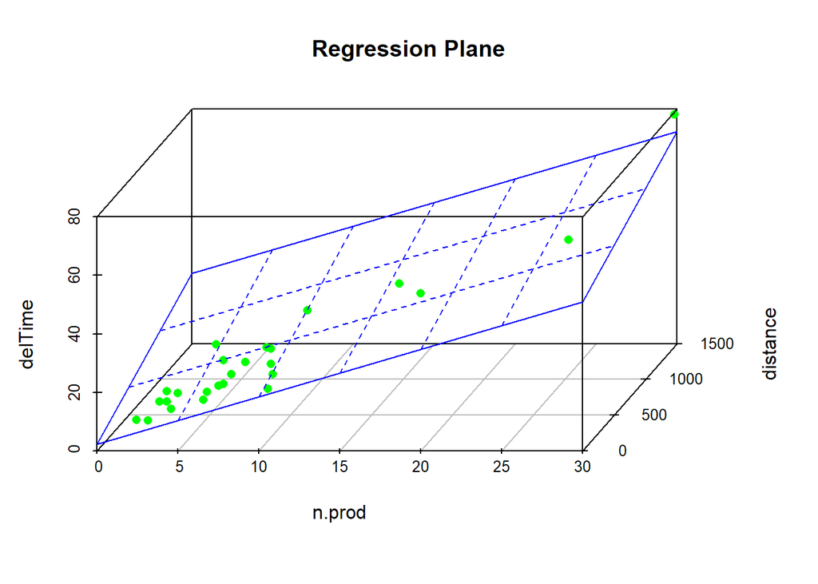

```r
library(scatterplot3d)
plot3d <- scatterplot3d(n.prod, distance, delTime, angle=55, scale.y=, pch=16, color="green", main="Regression Plane")
plot3d$plane3d(mod.reg, lty.box="solid", col="blue")
```

Persamaan regresi dugaan berikut berupa bidang:

$$\hat{Y} = 2.3412 + 1.6159X_1 + 0.0144X_2$$

# 2. Cek asumsi-asumsi dalam analisis regresi berganda

### 1) Asumsi Linearitas

```r
library(GGally)
```

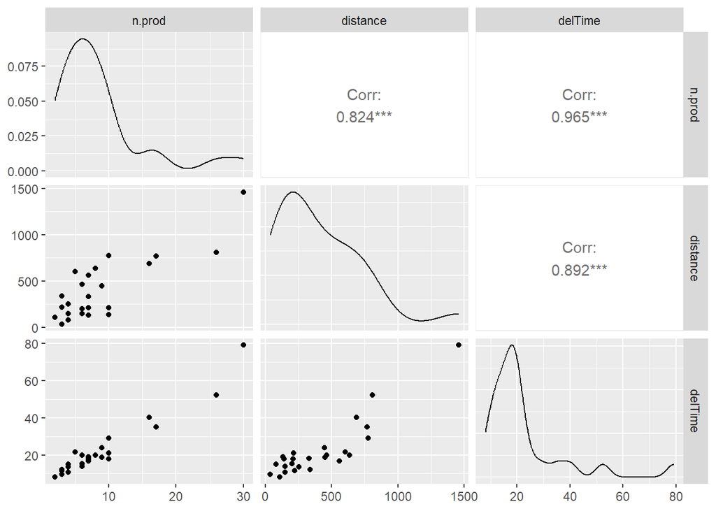

```r
ggpairs(data=data.frame(n.prod, distance, delTime))
```

### 2) Asumsi Nonmultikolinearitas

```r
library(car)
vif(mod.reg)
```

```
##   n.prod distance
## 3.118474 3.118474
```

### 3) Asumsi Normalitas

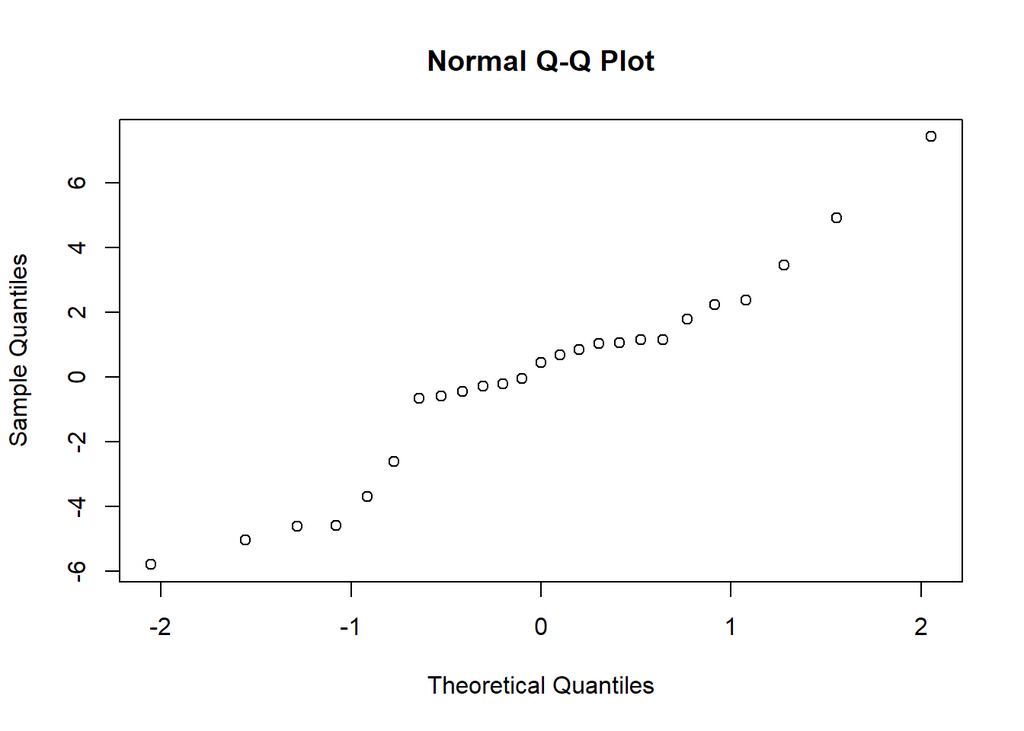

```r
qqnorm(resid(mod.reg))
```

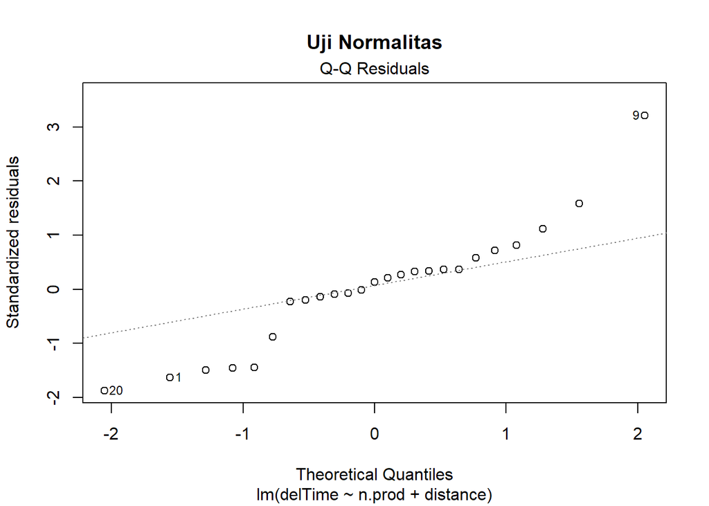

```r
plot(mod.reg,2, main="Uji Normalitas")
```

### 4) Asumsi Homogenitas

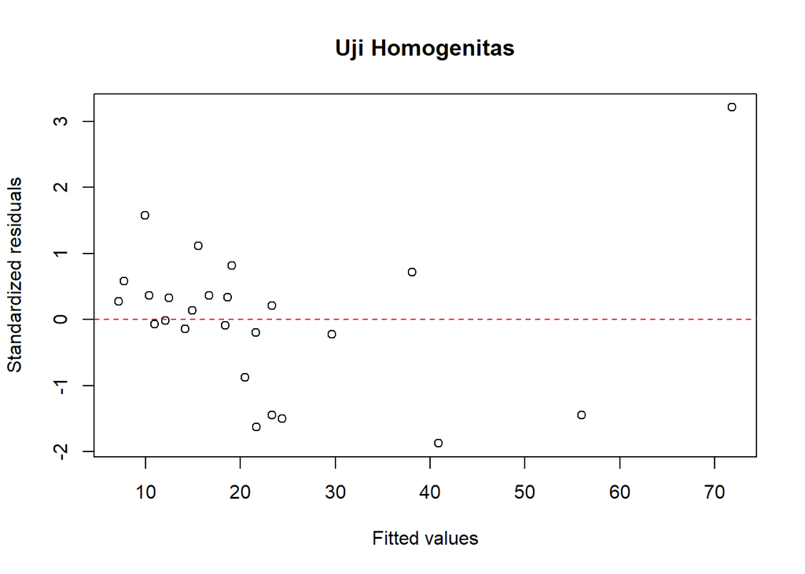

```r
library(MASS)
plot(fitted(mod.reg),stdres(mod.reg),xlab="Fitted values",ylab="Standardized residuals",main="Uji Homogenitas")
abline(h=0,lty=2,col="red")
```

Plot fitted values vs standardized residuals di atas menunjukkan bahwa tidak ada pola yang kuat pada residual dan titik-titik menyebar secara acak di atas dan di bawah sumbu 𝑌=0 (dalam pita horizontal) sehingga asumsi homogenitas variansi terpenuhi.

### 5) Asumsi Independen

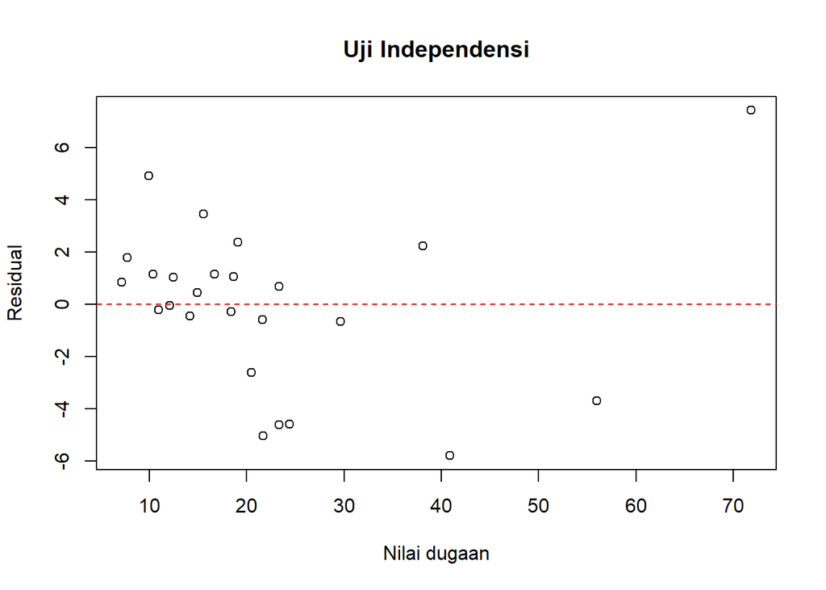

```r
plot(fitted(mod.reg),resid(mod.reg),xlab="Nilai dugaan",ylab="Residual",main="Uji Independensi")
abline(h=0,lty=2,col="red")
```

Plot uji independensi di atas menunjukkan bahwa titik-titik menyebar di sekitar garis horizontal 0, maka galat saling independen. Dapat disimpulkan bahwa asumsi independen terpenuhi.

# 3. Inferensi bagi parameter (pengujian hipotesis atau interval kepercayaan)

```r
# Uji hipotesis bagi signifikansi regresi linear ganda
anova_delivery <- anova(mod.reg)
anova_delivery
```

```
## Analysis of Variance Table
##
## Response: delTime
##           Df Sum Sq Mean Sq F value    Pr(>F)
## n.prod     1 5382.4  5382.4 506.619 < 2.2e-16 ***
## distance   1  168.4   168.4  15.851 0.0006312 ***
## Residuals 22  233.7    10.6
## ---
## Signif. codes:  0 '***' 0.001 '**' 0.01 '*' 0.05 '.' 0.1 ' ' 1
```

```r
qf(0.95,df1=2,df2=22)
```

```
## [1] 3.443357
```

```r
summary(mod.reg)
```

```
##
## Call:
## lm(formula = delTime ~ n.prod + distance)
##
## Residuals:
##     Min      1Q  Median      3Q     Max
## -5.7880 -0.6629  0.4364  1.1566  7.4197
##
## Coefficients:
##             Estimate Std. Error t value Pr(>|t|)
## (Intercept) 2.341231   1.096730   2.135 0.044170 *
## n.prod      1.615907   0.170735   9.464 3.25e-09 ***
## distance    0.014385   0.003613   3.981 0.000631 ***
## ---
## Signif. codes:  0 '***' 0.001 '**' 0.01 '*' 0.05 '.' 0.1 ' ' 1
##
## Residual standard error: 3.259 on 22 degrees of freedom
## Multiple R-squared:  0.9596, Adjusted R-squared:  0.9559
## F-statistic: 261.2 on 2 and 22 DF,  p-value: 4.687e-16
```